# lab27

Andrew Do

July 27, 2016

All the map functions in `purrr` take an interable object `.x` as their first argument. They then apply `.f` to each elemenet of `.x`. The type of object returned depends on the suffix (the part after `_`)

| Function | Returns |
| --- | --- |
| `map()` | list or data frame |
| `map_lgl` | logical vector |
| `map_int` | integer vector |
| `map_dbl` | double vector |
| `map_chr` | character vector |
| `map_df` | data frame |

A few things to note:

- `map()` is identical to `lapply()`. There are no computational advantages to using one over the other. The only difference is that `map()` is consistent with the other `map_*()` functions
- `sapply` automatically tries to simplify results, which is nice when you are exploring your data manually, but bad in scripts because it isn’t consistent

```r
x1 <- list(
  c(0.27, 0.37, 0.57, 0.91, 0.20),
  c(0.90, 0.94, 0.66, 0.63, 0.06),
  c(0.21, 0.18, 0.69, 0.38, 0.77)
)
x2 <- list(
  c(0.50, 0.72, 0.99, 0.38, 0.78),
  c(0.93, 0.21, 0.65, 0.13, 0.27),
  c(0.39, 0.01, 0.38, 0.87, 0.34)
)

threshold <- function(x, cutoff = 0.8) x[x > cutoff]
x1 %>% sapply(threshold) %>% str
```

```
## List of 3
##  $ : num 0.91
##  $ : num [1:2] 0.9 0.94
##  $ : num(0)
```

```r
x2 %>% sapply(threshold) %>% str
```

```
##  num [1:3] 0.99 0.93 0.87
```

- `vapply()` is safer than `sapply()` to use since you always specify the data type you want it to output. It has the disadvantage of being verbose.

```r
x1 %>% vapply(mean, numeric(1))
```

```
## [1] 0.464 0.638 0.446
```

```r
x1 %>% map_dbl(mean)
```

```
## [1] 0.464 0.638 0.446
```

### Your Turn

```r
x1 <- data.frame(x1) %>% setNames(letters[1:3])
```

Use map_dbl() to find column means

```r
# Your code here
x1 %>% map_dbl(mean)
```

```
##     a     b     c
## 0.464 0.638 0.446
```

Use map_dbl() to column medians

```r
# Your code here
x1 %>% map_dbl(median)
```

```
##    a    b    c
## 0.37 0.66 0.38
```

Use map_dbl() to find column standard deviations

```r
# Your code here
x1 %>% map_dbl(sd)
```

```
##         a         b         c
## 0.2856221 0.3515964 0.2717168
```

## Passing other arguments

Notice that the `map_*` functions have `...` like `lapply()`. This allows you to additional arguments to the function `.f`. For example, if you wanted to calculate a truncated mean by specifying the `trim` argument inside the `mean()` function:

```r
x1 %>% map_dbl(mean, trim = 0.25)
```

```
##         a         b         c
## 0.4033333 0.7300000 0.4266667
```

### Your turn

```r
planes <- nycflights13::planes
```

Find the column means of planes using `map_dbl`, ignoring NAs. Notice that `map` safely ignores columns where the mean doesn’t make sense.

```r
# Your code here
planes %>% map_dbl(mean, na.rm = TRUE)
```

```
##      tailnum         year         type manufacturer        model
##           NA  2000.484010           NA           NA           NA
##      engines        seats        speed       engine
##     1.995184   154.316376   236.782609           NA
```

Similarly, find the 5th percentile of each column using `quantile()`.

```r
# Your code here
planes[, c(2,8)] %>% map_dbl(quantile, probs = .05, na.rm = TRUE)
```

```
##   year  speed
## 1988.0   90.5
```

## Choosing the right `map_*()` function.

While you can always use `map()` to return a list, it’s always a good idea to think about the data type you actually want a script to return. The `map_*()` functions are **type consistent**, meaning they will always return the specified data type, a warning saying not all elements returned the specified type, or an error if all elements failed to return the specified type. In the example below, `map_lgl()` returns an error since none of the outputs were logical values.

```r
set.seed(2000)
df <- data.frame(a = rnorm(5), b = sample(c("A", "B"), 5, T), c = 1:5, stringsAsFactors = F)
df %>% map_lgl(mean)
```

```
## Error: Can't coerce element 1 from a double to a logical
```

### Your turn

Choose the appropriate map function to perform the following tasks on `df`:

Finding out which columns are numeric with `is.numeric()`.

```r
# Your code here
df %>% map_lgl(is.numeric)
```

```
##     a     b     c
##  TRUE FALSE  TRUE
```

Finding out the column types of each column using `typeof`.

```r
# Your code here
df %>% map_chr(typeof)
```

```
##           a           b           c
##    "double" "character"   "integer"
```

Finding a summary of each column with `summary`

```r
# Your code here
df %>% map(summary)
```

```
## $a
##    Min. 1st Qu.  Median    Mean 3rd Qu.    Max.
## -0.8538 -0.3529  0.8901  0.4682  0.9161  1.7410
##
## $b
##    Length     Class      Mode
##         5 character character
##
## $c
##    Min. 1st Qu.  Median    Mean 3rd Qu.    Max.
##       1       2       3       3       4       5
```

## Anonymous functions

Just like with `lapply()`, you can use anonymous functions inside `map_*` when you don’t want to explicitly create a function.

```r
df %>% map(function(x) sum(is.na(x)))
```

```
## $a
## [1] 0
##
## $b
## [1] 0
##
## $c
## [1] 0
```

Anonymous functions in `R` tend to be a little verbose, so `purrr` has a shortcut available for use. Using a `.` or `.x` to denote an element of `.x`, we can write a **formula** that does the same thing as an anonymous function in the following ways:

```r
df %>% map(~ sum(is.na(.)))
```

```
## $a
## [1] 0
##
## $b
## [1] 0
##
## $c
## [1] 0
```

```r
df %>% map(~ .x %>% is.na %>% sum)
```

```
## $a
## [1] 0
##
## $b
## [1] 0
##
## $c
## [1] 0
```

## Subsetting

One of the most common operations that gets anonymized is subsetting (with `[[]]`). For example:

```r
my_list <- list(
  list(a = 1, b = "a"),
  list(a = 2, b = "b"),
  list(a = 3, b = "c")
)

my_list %>% map_dbl(function(x) x[["a"]])
```

```
## [1] 1 2 3
```

The shortcut for subsetting is to either call on the desired element by name or position:

```r
my_list %>% map_dbl("a")
```

```
## [1] 1 2 3
```

```r
my_list %>% map_dbl(1)
```

```
## [1] 1 2 3
```

### Your turn

This code subsets the `mtcars` data set into 4, 6, and 8 cylinder engine cars and then performs a linear regression (“finds a line of best fit”) of `mpg` on `wt` with each of the subsets. The results are saved in `models`.

```r
models <- mtcars %>% split(mtcars$cyl) %>% map(~ lm(mpg ~ wt, data = .x))
```

The `coef()` function extracts the coefficients from a model. Use it in conjunction with `map()` to extract the coefficients of each model. Save the results in `coefficients`

```r
# Your code here
coefficients <- models %>% map(coef)
```

Using the string shortcut for subsetting, extract the `wt` coefficient of each model.

```r
# Your code here
coefficients %>% map_dbl("wt")
```

```
##         4         6         8
## -5.647025 -2.780106 -2.192438
```

## Nested Structures

You can extract deeply nested elements of a list using character vectors. A common example of when this might occur is when working with JSON data. Take for example, these issues taken from the GitHub API:

```r
issues <- jsonlite::fromJSON("issues.json", simplifyVector = FALSE)
```

Examining the data reveals that there are 8 issues, each in a nested list

```r
length(issues)
```

```
## [1] 8
```

```r
str(issues)
```

```
## List of 8
##  $ :List of 20
##   ..$ url         : chr "https://api.github.com/repos/hadley/r4ds/issues/11"
##   ..$ labels_url  : chr "https://api.github.com/repos/hadley/r4ds/issues/11/labels{/name}"
##   ..$ comments_url: chr "https://api.github.com/repos/hadley/r4ds/issues/11/comments"
##   ..$ events_url  : chr "https://api.github.com/repos/hadley/r4ds/issues/11/events"
##   ..$ html_url    : chr "https://github.com/hadley/r4ds/pull/11"
##   ..$ id          : int 117521642
##   ..$ number      : int 11
##   ..$ title       : chr "Typo correction in file expressing-yourself.Rmd"
##   ..$ user        :List of 17
##   .. ..$ login              : chr "shoili"
##   .. ..$ id                 : int 8914139
##   .. ..$ avatar_url         : chr "https://avatars.githubusercontent.com/u/8914139?v=3"
##   .. ..$ gravatar_id        : chr ""
##   .. ..$ url                : chr "https://api.github.com/users/shoili"
##   .. ..$ html_url           : chr "https://github.com/shoili"
##   .. ..$ followers_url      : chr "https://api.github.com/users/shoili/followers"
##   .. ..$ following_url      : chr "https://api.github.com/users/shoili/following{/other_user}"
##   .. ..$ gists_url          : chr "https://api.github.com/users/shoili/gists{/gist_id}"
##   .. ..$ starred_url        : chr "https://api.github.com/users/shoili/starred{/owner}{/repo}"
##   .. ..$ subscriptions_url  : chr "https://api.github.com/users/shoili/subscriptions"
##   .. ..$ organizations_url  : chr "https://api.github.com/users/shoili/orgs"
##   .. ..$ repos_url          : chr "https://api.github.com/users/shoili/repos"
##   .. ..$ events_url         : chr "https://api.github.com/users/shoili/events{/privacy}"
##   .. ..$ received_events_url: chr "https://api.github.com/users/shoili/received_events"
##   .. ..$ type               : chr "User"
##   .. ..$ site_admin         : logi FALSE
##   ..$ labels      : list()
##   ..$ state       : chr "open"
##   ..$ locked      : logi FALSE
##   ..$ assignee    : NULL
##   ..$ milestone   : NULL
##   ..$ comments    : int 0
##   ..$ created_at  : chr "2015-11-18T06:26:09Z"
##   ..$ updated_at  : chr "2015-11-18T06:26:09Z"
##   ..$ closed_at   : NULL
##   ..$ pull_request:List of 4
##   .. ..$ url      : chr "https://api.github.com/repos/hadley/r4ds/pulls/11"
##   .. ..$ html_url : chr "https://github.com/hadley/r4ds/pull/11"
```

[output cut: 257 more lines]

```
##   .. ..$ repos_url          : chr "https://api.github.com/users/hadley/repos"
##   .. ..$ events_url         : chr "https://api.github.com/users/hadley/events{/privacy}"
##   .. ..$ received_events_url: chr "https://api.github.com/users/hadley/received_events"
##   .. ..$ type               : chr "User"
##   .. ..$ site_admin         : logi FALSE
##   ..$ labels      : list()
##   ..$ state       : chr "open"
##   ..$ locked      : logi FALSE
##   ..$ assignee    : NULL
##   ..$ milestone   : NULL
##   ..$ comments    : int 1
##   ..$ created_at  : chr "2015-08-06T13:05:44Z"
##   ..$ updated_at  : chr "2015-08-06T13:22:48Z"
##   ..$ closed_at   : NULL
##   ..$ body        : chr "http://simplefocus.com/flowtype/"
```

You could extract the user login and id by traveling down the tree in two steps, first through user and then accessing login and id.

```r
users <- issues %>% map("user")
users %>% map_chr("login")
```

```
## [1] "shoili"     "benmarwick" "datalove"   "hadley"     "hadley"
## [6] "hadley"     "hadley"     "hadley"
```

```r
users %>% map_int("id")
```

```
## [1] 8914139 1262179  222907    4196    4196    4196    4196    4196
```

However, you could also traverse the tree in a single step, by specifying a character vector:

```r
issues %>% map_chr(c("user", "login"))
```

```
## [1] "shoili"     "benmarwick" "datalove"   "hadley"     "hadley"
## [6] "hadley"     "hadley"     "hadley"
```

```r
issues %>% map_int(c("user", "id"))
```

```
## [1] 8914139 1262179  222907    4196    4196    4196    4196    4196
```

## Removing a level of the hierarchy

Sometimes you want to remove a level of your tree altogether, collecting all the children in one list. The `flatten_*()` functions in `purrr` take care of this. Like with map, they are typed, so you have `flatten()`, `flatten_lgl()`, `flatten_int()`, `flatten_dbl()`, and `flatten_chr()`. In the code below, we flatten a list of lists of double vectors into a list of double vectors, and then to a vector.

```r
x <- list(list(a = 1, b = 2), list(c = 3, d = 4))
str(x)
```

```
## List of 2
##  $ :List of 2
##   ..$ a: num 1
##   ..$ b: num 2
##  $ :List of 2
##   ..$ c: num 3
##   ..$ d: num 4
```

```r
y <- flatten(x)
str(y)
```

```
## List of 4
##  $ a: num 1
##  $ b: num 2
##  $ c: num 3
##  $ d: num 4
```

```r
flatten_dbl(y)
```

```
## [1] 1 2 3 4
```

Visually, this is what’s happening:

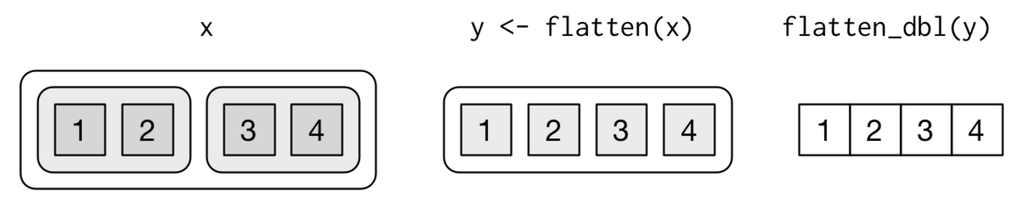

## Transposing

Sometimes the tree feels a little “inside-out”. You can use `transpose()` to flip the first and second levels of a list:

```r
x <- list(
  x = list(a = 1, b = 3, c = 5),
  y = list(a = 2, b = 4, c = 6)
)
x %>% str()
```

```
## List of 2
##  $ x:List of 3
##   ..$ a: num 1
##   ..$ b: num 3
##   ..$ c: num 5
##  $ y:List of 3
##   ..$ a: num 2
##   ..$ b: num 4
##   ..$ c: num 6
```

```r
x %>% transpose() %>% str()
```

```
## List of 3
##  $ a:List of 2
##   ..$ x: num 1
##   ..$ y: num 2
##  $ b:List of 2
##   ..$ x: num 3
##   ..$ y: num 4
##  $ c:List of 2
##   ..$ x: num 5
##   ..$ y: num 6
```

Visually, this is what we have:

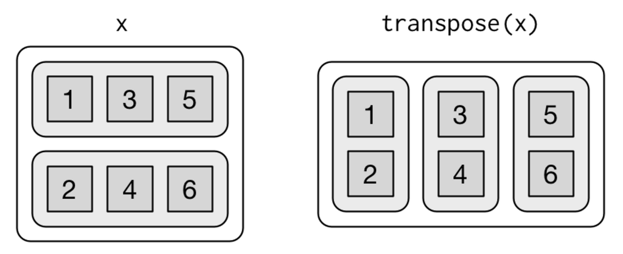

Transposing is very useful when working with JSON APIs since many JSON data sources represent their data in a row-based format whereas R is more naturally a column-based format.